# BTC comparision

## P1 Introduction

Since the emergence of Bitcoin in 2009, various digital currencies have begun to emerge. This type of currency, which was originally created to resist the abuse of currency and promote social fairness and efficiency, has many differences in the way of currency creation, storage, and circulation from the current global legal currency. From a social point of view. On the one hand, as an application of blockchain technology, digital currency has many good application scenarios. On the other hand, as a new thing, digital currency has many drawbacks, such as its anonymity, which is easily used by many elements for money laundering and other illegal and criminal funds and transaction.The low transparency of market information makes the price of digital currency easy to be manipulated and thus harm the interests of investors  
However, from the perspective of financial market research, the development of digital currency has become a brand new type of asset. Studying this emerging financial asset, which is very different from traditional assets, can help us understand the nature of financial transactions more deeply. In this project, three different types of RNN model are used to perform regression tasks to fit the prices of Bitcoin in the past few years.

### P1.1 Data Exploration

Read data into dataframe

```python
import numpy as np
import pandas as pd
import matplotlib.pyplot as plt
```

```python
dataset_train = pd.read_csv("./BTC_trainset.csv")
trainset = dataset_train.iloc[:,1:2].values
```

A glance of the data

```python
dataset_train.head()
```

|  | Date | Open | High | Low | Close | Adj Close | Volume |
| --- | --- | --- | --- | --- | --- | --- | --- |
| 0 | 2017/12/28 | 15864.09961 | 15888.40039 | 13937.29981 | 14606.50000 | 14606.50000 | 1.233650e+10 |
| 1 | 2017/12/29 | 14695.79981 | 15279.00000 | 14307.00000 | 14656.20020 | 14656.20020 | 1.302550e+10 |
| 2 | 2017/12/30 | 14681.90039 | 14681.90039 | 12350.09961 | 12952.20020 | 12952.20020 | 1.445260e+10 |
| 3 | 2017/12/31 | 12897.70020 | 14377.40039 | 12755.59961 | 14156.40039 | 14156.40039 | 1.213630e+10 |
| 4 | 2018/1/1 | 14112.20020 | 14112.20020 | 13154.70020 | 13657.20020 | 13657.20020 | 1.029120e+10 |

Statistic description of the dataset

```python
dataset_train.describe()
```

|  | Open | High | Low | Close | Adj Close | Volume |
| --- | --- | --- | --- | --- | --- | --- |
| count | 1196.000000 | 1196.000000 | 1196.000000 | 1196.000000 | 1196.000000 | 1.196000e+03 |
| mean | 11845.659557 | 12165.719460 | 11513.050846 | 11880.344246 | 11880.344246 | 2.227043e+10 |
| std | 11355.113117 | 11750.524234 | 10961.120152 | 11435.391226 | 11435.391226 | 2.079855e+10 |
| min | 3236.274658 | 3275.377930 | 3191.303467 | 3236.761719 | 3236.761719 | 2.923670e+09 |
| 25% | 6636.644897 | 6763.397461 | 6536.082154 | 6638.435059 | 6638.435059 | 6.523269e+09 |
| 50% | 8738.998535 | 8904.386719 | 8522.830566 | 8739.969238 | 8739.969238 | 1.748735e+10 |
| 75% | 10807.464355 | 11056.049070 | 10519.308108 | 10807.289553 | 10807.289553 | 3.080630e+10 |
| max | 61221.132810 | 61683.863280 | 59302.316410 | 61243.085940 | 61243.085940 | 3.510000e+11 |

Minmax scaler is used to unified the data for faster converge speed during the trainning process.

```python
from sklearn.preprocessing import MinMaxScaler
sc = MinMaxScaler(feature_range = (0,1))
training_scaled = sc.fit_transform(trainset)
```

```python
x_train = []
y_train = []
```

Since this is a time series data, I assume the datapoint can be predicted by previous 60 datapoints. Why 60? In stock market, 60 day MACD line is an important feature to predict the price of a stock. I tried 20 datapoints as features (MACD 20 line is also important in stock analysis.), but the results are bad comparing to 60 datapoints.

```python
# For each datapoint, make the 60 datapoints right before it to be the features of it.
for i in range(60,1196):
    x_train.append(training_scaled[i-60:i, 0])
    y_train.append(training_scaled[i,0])
x_train,y_train = np.array(x_train),np.array(y_train)
x_train = np.reshape(x_train, (x_train.shape[0],x_train.shape[1],1))
```

### P2 Model setup

RNN models are developed for sequence data machine learning, and has been proved to be a successful model in related applications. RNN model started from simple-RNN nodes, and then got improved with LSTM nodes, recent years witnessed the application of GRU nodes.  
How would these 3 models perform in a task to fit a curve of Bitcoin prices? I have assumption that GRU is better than LSTM and LSTM is better than simple RNN. The assumption didn't come from random guess. An instiution formed from the history of RNN that the newer model beats the old one. Another reason is that I searched the internet and lots of work supported my assumption.  
Is it true or not? I built 3 models to explored the answer.

```python
from keras.models import Sequential
from keras.layers import Dense
from keras.layers import LSTM, SimpleRNN, GRU
from keras.layers import Dropout
```

To focus on the research of different nodes, other perspective of the models are strictly controlled to be the same， including the model structure and trainning method.

```python
simple_rnn = Sequential()
simple_rnn.add(SimpleRNN(units = 50,return_sequences = True,input_shape = (x_train.shape[1],1)))
simple_rnn.add(Dropout(0.2))
simple_rnn.add(SimpleRNN(units = 50,return_sequences = True))
simple_rnn.add(Dropout(0.2))
simple_rnn.add(SimpleRNN(units = 50,return_sequences = True))
simple_rnn.add(Dropout(0.2))
simple_rnn.add(SimpleRNN(units = 50))
simple_rnn.add(Dropout(0.2))
simple_rnn.add(Dense(units = 1))


lstm = Sequential()
lstm.add(LSTM(units = 50,return_sequences = True,input_shape = (x_train.shape[1],1)))
lstm.add(Dropout(0.2))
lstm.add(LSTM(units = 50,return_sequences = True))
lstm.add(Dropout(0.2))
lstm.add(LSTM(units = 50,return_sequences = True))
lstm.add(Dropout(0.2))
lstm.add(LSTM(units = 50))
lstm.add(Dropout(0.2))
lstm.add(Dense(units = 1))


gru = Sequential()
gru.add(GRU(units = 50,return_sequences = True,input_shape = (x_train.shape[1],1)))
gru.add(Dropout(0.2))
gru.add(GRU(units = 50,return_sequences = True))
gru.add(Dropout(0.2))
gru.add(GRU(units = 50,return_sequences = True))
gru.add(Dropout(0.2))
gru.add(GRU(units = 50))
gru.add(Dropout(0.2))
gru.add(Dense(units = 1))
```

```python
simple_rnn.compile(optimizer = 'adam',loss = 'mean_squared_error')
simple_rnn.fit(x_train,y_train,epochs = 100, batch_size = 32)

lstm.compile(optimizer = 'adam',loss = 'mean_squared_error')
lstm.fit(x_train,y_train,epochs = 100, batch_size = 32)

gru.compile(optimizer = 'adam',loss = 'mean_squared_error')
gru.fit(x_train,y_train,epochs = 100, batch_size = 32)
```

```
<tensorflow.python.keras.callbacks.History at 0x19c3d8cf400>
```

### P3 Results

```python
dataset_test =pd.read_csv("./BTC_testset.csv")
real_price = dataset_test.iloc[:,1:2].values

dataset_total = pd.concat((dataset_train['Open'],dataset_test['Open']),axis = 0)
inputs = dataset_total[len(dataset_total) - len(dataset_test)-60:].values
inputs = inputs.reshape(-1,1)
inputs = sc.transform(inputs)
inputs.shape
```

```
(263, 1)
```

```python
x_test = []
for i in range(60,263):
    x_test.append(inputs[i-60:i,0])
```

```python
x_test = np.array(x_test)
x_test = np.reshape(x_test, (x_test.shape[0],x_test.shape[1],1))
```

```python
from sklearn.metrics import mean_squared_error
```

```
Mean squared error: 10405302.29
```

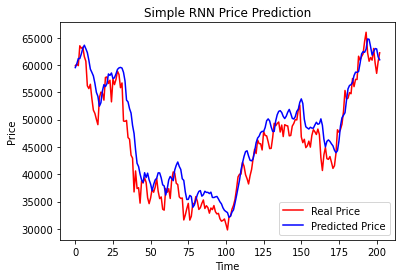

```python
predicted_price = simple_rnn.predict(x_test)
predicted_price = sc.inverse_transform(predicted_price)
print("Mean squared error: %.2f" % mean_squared_error(real_price, predicted_price))
plt.plot(real_price,color = 'red', label = 'Real Price')
plt.plot(predicted_price, color = 'blue', label = 'Predicted Price')
plt.title('Simple RNN Price Prediction')
plt.xlabel('Time')
plt.ylabel('Price')
plt.legend()
plt.show()
```

```
Mean squared error: 85684339.62
```

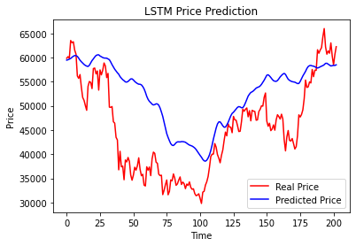

```python
predicted_price = lstm.predict(x_test)
predicted_price = sc.inverse_transform(predicted_price)
print("Mean squared error: %.2f" % mean_squared_error(real_price, predicted_price))
plt.plot(real_price,color = 'red', label = 'Real Price')
plt.plot(predicted_price, color = 'blue', label = 'Predicted Price')
plt.title('LSTM Price Prediction')
plt.xlabel('Time')
plt.ylabel('Price')
plt.legend()
plt.show()
```

```
Mean squared error: 6891456.86
```

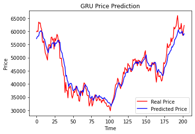

```python
predicted_price = gru.predict(x_test)
predicted_price = sc.inverse_transform(predicted_price)
print("Mean squared error: %.2f" % mean_squared_error(real_price, predicted_price))
plt.plot(real_price,color = 'red', label = 'Real Price')
plt.plot(predicted_price, color = 'blue', label = 'Predicted Price')
plt.title('GRU Price Prediction')
plt.xlabel('Time')
plt.ylabel('Price')
plt.legend()
plt.show()
```

### P3.1 Result analysis and conclusion

As shown above, the simple RNN and GRU model show much better fitting curve than the LSTM, and GRU is also better than RNN from the MSE loss. This means that the assumption stated in P2 is false. Conclusion: In real life projects, it's common to evaluate several models and select the best one or combine them to achive better performance.